# Step-by-step guide to the MO-Coxmos pipeline

Pedro Salguero García

Polytechnic University of Valencia and Institute for Integrative Systems Biology (I2SysBio), Valencia, Spain  
pedrosalguerog@gmail.com

Last updated: 14 septiembre, 2023

# Introduction

The **Coxmos** R package includes the following basic analysis blocks:

1. **Cross-validation and Modeling for High-Dimensional Data**: The user can use the *Coxmos* package to select the optimal parameters for survival models in high-dimensional datasets. The package provides tools for estimating the best values for the parameters.
2. **Comparing Classical and High-Dimensional Survival Models**: After obtaining multiple survival models, the user can compare them to determine which one gives the best results. The package includes several functions for comparing the models.
3. **Interpreting Results**: After selecting the best model or models, the user can interpret the results. The package includes several functions for understanding the impact of the original variables on survival prediction, even when working with (s)PLS methods.
4. **Predicting New Patients**: Finally, if a new dataset of patients is available, the user can use the model to make predictions for the new patients and compare the variables against the model coefficients to estimate the patients’ risk of an event.

# Installation

Coxmos can be installed from GitHub using `devtools`:

```r
install.packages("devtools")
devtools::install_github("ConesaLab/Coxmos", build_vignettes = TRUE)
```

# Getting ready

To run the analyses in this vignette, you’ll first need to load `Coxmos`:

```r
# load Coxmos
library(Coxmos)
```

In addition, we’ll require some additional packages for data formatting. Most of them are signaled as `Coxmos` dependencies, so they will already be installed in your system.

To generate plots, we make use of the `RColorConesa` R package. After install:

```r
# install.packages("devtools")
devtools::install_github("ConesaLab/RColorConesa")
```

After the installation you can load and set the *theme* of your R session as follows:

```r
library(RColorConesa)
#theme_set(theme_colorConesa()) #under development
```

# Input data

The Coxmos pipeline requires two matrices as input. First one must be the features under study, and the second one a matrix with two columns called **time** and **event** for survival information.

After quality control, the data contains expression data for miRNAs and Protein information. The data could be load as follows:

```r
# load dataset
data("X_multiomic", package = "Coxmos")
data("Y_multiomic", package = "Coxmos")

X <- X_multiomic
Y <- Y_multiomic

rm(X_multiomic, Y_multiomic)
```

These files contain a `list` of two blocks and a `data.frame` object. Our toy example has a total of **150 observations, 642 miRNAs and 369 proteins**:

|  | hsa-let-7a-2-3p | hsa-let-7a-3p | hsa-let-7a-5p | hsa-let-7b-3p | hsa-let-7b-5p |
| --- | --- | --- | --- | --- | --- |
| TCGA-A2-A0SV-01A | 9.344533 | 228.00660 | 56661.51 | 155.1192 | 57564.19 |
| TCGA-A2-A0YT-01A | 25.031847 | 134.54618 | 56991.26 | 103.2564 | 64478.91 |
| TCGA-BH-A1F0-01A | 34.725664 | 122.98673 | 68110.05 | 195.3319 | 37871.23 |
| TCGA-B6-A0IK-01A | 44.962897 | 163.66495 | 89585.87 | 183.4486 | 121455.58 |
| TCGA-E2-A1LE-01A | 15.392269 | 87.54353 | 188649.57 | 109.6699 | 54892.68 |

|  | 7529 | 7531 | 7534 | 1978 | 7158 |
| --- | --- | --- | --- | --- | --- |
| TCGA-A2-A0SV-01A | 0.025273 | -0.030661 | 0.458350 | 1.369000 | -0.40781 |
| TCGA-A2-A0YT-01A | 0.348210 | 0.347870 | 0.891570 | -0.188540 | -0.13896 |
| TCGA-BH-A1F0-01A | 0.132340 | -0.348210 | 0.078923 | 0.227890 | -0.49063 |
| TCGA-B6-A0IK-01A | 0.352670 | 0.376670 | -0.285750 | -0.380980 | -1.43080 |
| TCGA-E2-A1LE-01A | 0.110140 | 0.094990 | -0.159960 | -0.098148 | 0.40160 |

|  | time | event |
| --- | --- | --- |
| TCGA-A2-A0SV-01A | 825 | TRUE |
| TCGA-A2-A0YT-01A | 723 | TRUE |
| TCGA-BH-A1F0-01A | 785 | TRUE |
| TCGA-B6-A0IK-01A | 571 | TRUE |
| TCGA-E2-A1LE-01A | 879 | TRUE |

As can be observed, clinical variables were transform to binary/dummy variables for factors.

```r
ggp_density.event <- plot_events(Y = Y,
                                 categories = c("Censored","Death"), #name for FALSE/0 (Censored) and TRUE/1 (Event)
                                 y.text = "Number of observations",
                                 roundTo = 0.5,
                                 max.breaks = 15)
```

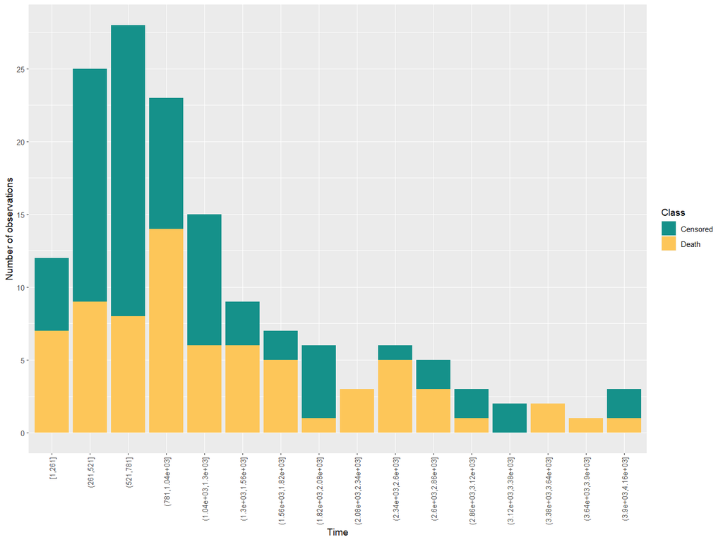

```r
ggp_density.event$plot
```

# Survival models for multiomic data sets

After loading the data, it may be of interest for the user to perform a survival analysis in order to examine the relationship between explanatory variables and the outcome. However, traditional methods are only applicable for low-dimensional datasets. To address this issue, we have developed a set of functions that make use of (s)PLS techniques in combination with Cox analysis for the analysis of high-dimensional datasets.

*Coxmos* provides the following methodologies for multi-omic approaches:

- SB.sPLS approaches: SB.sPLS-ICOX, iSB.sPLS-ICOX, SB.sPLS-DRCOX and iSB.sPLS-DRCOX.
- MB.sPLS approaches: MB.sPLS-DRCOX-Dynamic and MB.sPLS-DACOX-Dynamic.

More information for each approach could be found in the help section for each function. The function name for each methodology are:

- SB.sPLS approaches: `sb.splsicox()`, `cv.isb.splsicox()`, `sb.splsdrcox()` and `cv.isb.splsdrcox()`.
- MB.sPLS approaches: `mb.splsdrcox()` and `mb.splsdacox()`.

To perform a survival analysis with our example, we will use methodologies that can work with high-dimensional data. These are the set of methodologies that use sPLS techniques.

The first thing we are going to do is split our data into a train and test set. This split will be made with a proportion of 70% of the data for training and 30% for testing.

## TRAIN/TEST

We will use the function `createDataPartition` from the R package **caret**. We will use a 70% - 30% split for training and testing, respectively, and set a seed for reproducible results.

```r
set.seed(123)
index_train <- caret::createDataPartition(Y$event,
                                          p = .7, #70 %
                                          list = FALSE,
                                          times = 1)

X_train <- list()
X_test <- list()
for(omic in names(X)){
  X_train[[omic]] <- X[[omic]][index_train,,drop=F]
  X_test[[omic]] <- X[[omic]][-index_train,,drop=F]
}

Y_train <- Y[index_train,]
Y_test <- Y[-index_train,]
```

EVP per block:

```r
EPV <- getEPV.mb(X_train, Y_train)
for(b in names(X_train)){
  message(paste0("EPV = ", round(EPV[[b]], 4), ", for block ", b))
}
```

```
#> EPV = 0.0794, for block mirna
#> EPV = 0.1382, for block proteomic
```

## Cross Validation

In order to perform survival analysis with our high-dimensional data, we have implemented a series of methods that utilize techniques such as Cox Elastic Net, to select a lower number of features applying a penalty or partial least squares (PLS) methodology in order to reduce the dimensionality of the input data.

To evaluate the performance of these methods, we have implemented cross-validation, which allows us to estimate the optimal parameters for future predictions based on prediction metrics such as: **AIC**, **C-INDEX**, **I.BRIER** and **AUC**. By default AUC metric (Area under the ROC curve) is used with the “cenROC” evaluator as it has provided the best results in our tests. However, multiple **AUC** evaluators could be used: “risksetROC”, “survivalROC”, “cenROC”, “nsROC”, “smoothROCtime_C” and “smoothROCtime_I”.

Furthermore, a mix of multiple metrics could be used to obtain the optimal model. The user has to establish different weight for each emtric and all of them will be consider to compute the optimal model (the total weight must sum 1).

In addition, we have included options for normalizing data, filtering variables, and setting the minimum EPV, as well as specific parameters for each method, such as the alpha value for Cox Elastic Net and the number of components for PLS models. Overall, our cross-validation methodology allows us to effectively analyze high-dimensional survival data and optimize our model parameters.

## Preprocessing

As classical and PLS approach can not be perform in multiomic data, several multiomic methods have been designed. The methods are divided into two categories:

1. **Single-Block approach**: Each omic will be studied individually to reduce their dimensionality in order to explain the survival. Then, integration of all omics will be run to obtain the final model.
2. **Multi-Omic-Block approach**: All omics will be studied together by multiblock sPLS functions. After reduce the dimensionality, the latent variables will be used to obtain the final model.

But first, we establish the center and scale for each block:

```r
x.center = c(mirna = T, proteomic = T) #if vector, must be named
x.scale = c(mirna = F, proteomic = F) #if vector, must be named
```